# Youth Bahavior analysis

Priya Singh

2/15/2020

```r
library(rmarkdown)
library(readr)  ## after every package installed
library(readxl)
library(plyr)
library(dplyr)
```

```r
library(ggplot2)
library(leaflet)
library(plotly)
library(gridExtra)
library(knitr)
library(shiny)
library(scales)
library(cluster)
library(tidyverse)
library(Hmisc)
library(odbc)
library(forcats)
library(DBI)
library(wordcloud)
library(tidyverse)
library(Amelia)
library(fuzzyjoin)
library(stringr)
```

```r
Youth_behavior_data <- read_excel("C:/Users/prath/Documents/anly 699/Youth_data.xlsx")
```

## Descriptive data analysis of the variables

```r
summary(Youth_behavior_data)
```

## Data pre processing

1. Converting numeric data into factors
2. Coding the variables to plot graphs

```r
## Recoding Youth_behavior_data$age into ## Recoding Youth_behavior_data$grade into Youth_behavior_data$grade_rec
Youth_behavior_data$grade_rec <- as.character(Youth_behavior_data$grade)
Youth_behavior_data$grade_rec <- fct_recode(Youth_behavior_data$grade_rec,
               "11th grade" = "3",
               "10th grade" = "2",
               "9th grade" = "1",
               "12th grade" = "4")
Youth_behavior_data$age_rec <- as.character(Youth_behavior_data$age)
Youth_behavior_data$age_rec <- fct_recode(Youth_behavior_data$age_rec,
               "16 years old" = "5",
               "12 years old or younger" = "1",
               "14 years old" = "3",
               "15 years old" = "4",
               "17 years old" = "6",
               "18 years old or older" = "7",
               "13 years old" = "2")


## Recoding Youth_behavior_data$sex into Youth_behavior_data$sex_rec
Youth_behavior_data$sex_rec <- as.character(Youth_behavior_data$sex)
Youth_behavior_data$sex_rec <- fct_recode(Youth_behavior_data$sex_rec,
               "Male" = "2",
               "Female" = "1")


## Recoding Youth_behavior_data$race7 into Youth_behavior_data$race7_rec
Youth_behavior_data$race7_rec <- as.character(Youth_behavior_data$race7)
Youth_behavior_data$race7_rec <- fct_recode(Youth_behavior_data$race7_rec,
               "White" = "6",
               "Black or African American" = "3",
               "Asian" = "2",
               "Multiple Races (Non-Hispanic)" = "7",
               "Hispanic/ Latino" = "4",
               "Native Hawaiian/Other Pacific Islander" = "5",
               "American Indian/Alaska Native" = "1")

## Recoding Youth_behavior_data$qnobese into Youth_behavior_data$qnobese_rec
Youth_behavior_data$qnobese_rec <- as.character(Youth_behavior_data$qnobese)
Youth_behavior_data$qnobese_rec <- fct_recode(Youth_behavior_data$qnobese_rec,
               "No" = "2",
               "Yes" = "1")

## Recoding Youth_behavior_data$qnowt into Youth_behavior_data$qnowt_rec
Youth_behavior_data$qnowt_rec <- as.character(Youth_behavior_data$qnowt)
Youth_behavior_data$qnowt_rec <- fct_recode(Youth_behavior_data$qnowt_rec,
               "No" = "2",
               "Yes" = "1")

## Recoding Youth_behavior_data$sexid into Youth_behavior_data$sexid_rec
Youth_behavior_data$sexid_rec <- as.character(Youth_behavior_data$sexid)
Youth_behavior_data$sexid_rec <- fct_recode(Youth_behavior_data$sexid_rec,
               "Heterosexual (straight)" = "1",
               "Not sure" = "4",
               "Gay or lesbian" = "2",
               "Bisexual" = "3")

## Recoding Youth_behavior_data$q68 into Youth_behavior_data$q68_rec
Youth_behavior_data$q68_rec <- fct_recode(Youth_behavior_data$q68,
               "Slightly underweight" = "2",
               "Slightly overweight" = "4",
               "About the right weight" = "3",
               "Very overweight" = "5",
               "Very underweight" = "1")

## Recoding Youth_behavior_data$q69 into Youth_behavior_data$q69_rec
Youth_behavior_data$q69_rec <- fct_recode(Youth_behavior_data$q69,
               "Gain weight" = "2",
               "Lose weight" = "1",
               "I am not trying to do anything about my weight" = "4",
               "Stay the same weight" = "3")

## Recoding Youth_behavior_data$q70 into Youth_behavior_data$q70_rec
Youth_behavior_data$q70_rec <- fct_recode(Youth_behavior_data$q70,
               "1 to 3 times" = "2",
               "4 to 6 times" = "3",
               "Did not drink fruit juice" = "1",
               "2 times per day" = "5",
               "1 time per day" = "4",
               "4 or more times per day" = "7",
               "3 times per day" = "6")

## Recoding Youth_behavior_data$q71 into Youth_behavior_data$q71_rec
Youth_behavior_data$q71_rec <- fct_recode(Youth_behavior_data$q71,
               "4 to 6 times per day" = "3",
               "3 times per day" = "7",
               "1 to 3 times per day" = "2",
               "3 times per day" = "6",
               "2 times per day" = "5",
               "1 time per day" = "4",
               "Did not eat fruits" = "1")

## Recoding Youth_behavior_data$q72 into Youth_behavior_data$q72_rec
Youth_behavior_data$q72_rec <- fct_recode(Youth_behavior_data$q72,
               "1 to 3 times" = "2",
               "Did not eat green salad" = "1",
               "3 times per day" = "6",
               "4 to 6 times" = "3",
               "1 time per day" = "4",
               "4 or more times per day" = "7",
               "2 times per day" = "5")
## Recoding Youth_behavior_data$q76 into Youth_behavior_data$q76_rec
Youth_behavior_data$q76_rec <- fct_recode(Youth_behavior_data$q76,
               "4 to 6 times" = "3",
               "1 to 3 tim" = "2",
               "2 times per day" = "5",
               "Did not drink soda or pop" = "1",
               "4 or more times per day" = "7",
               "3 times per day" = "6",
               "1 time per day" = "4")
## Recoding Youth_behavior_data$q77 into Youth_behavior_data$q77_rec
Youth_behavior_data$q77_rec <- fct_recode(Youth_behavior_data$q77,
               "4 to 6 glasses" = "3",
               "4 or more glasses per day" = "7",
               "1 to 3 glasses" = "2",
               "1 glass per day" = "4",
               "3 glasses per day" = "6",
               "Did not drink milk" = "1",
               "2 glasses per day" = "5")
## Recoding Youth_behavior_data$q78 into Youth_behavior_data$q78_rec
Youth_behavior_data$q78_rec <- fct_recode(Youth_behavior_data$q78,
               "7 days" = "8",
               "4 days" = "5",
               "5 days" = "6",
               "3 days" = "4",
               "0 days" = "1",
               "2 days" = "3",
               "6 days" = "7",
               "1 day" = "2")

## Recoding Youth_behavior_data$q78 into Youth_behavior_data$q78_rec
Youth_behavior_data$q79_rec <- fct_recode(Youth_behavior_data$q79,
               "7 days" = "8",
               "4 days" = "5",
               "5 days" = "6",
               "3 days" = "4",
               "0 days" = "1",
               "2 days" = "3",
               "6 days" = "7",
               "1 day" = "2")

## Recoding Youth_behavior_data$q80 into Youth_behavior_data$q80_rec
Youth_behavior_data$q80_rec <- fct_recode(Youth_behavior_data$q80,
               "Less than 1 hour per day" = "2",
               "2 hours per day" = "4",
               "3 hours per day" = "5",
               "No TV on average school day" = "1",
               "1 hour per day" = "3",
               "5 or more hours per day" = "7",
               "4 hours per day" = "6")

## Recoding Youth_behavior_data$q23 into Youth_behavior_data$q23_rec
Youth_behavior_data$q23_rec <- fct_recode(Youth_behavior_data$q23,
               "No" = "2",
               "Yes" = "1")

## Recoding Youth_behavior_data$q30 into Youth_behavior_data$q30_rec
Youth_behavior_data$q30_rec <- fct_recode(Youth_behavior_data$q30,
               "No" = "2",
               "Yes" = "1")

## Recoding Youth_behavior_data$q40 into Youth_behavior_data$q40_rec
Youth_behavior_data$q40_rec <- fct_recode(Youth_behavior_data$q40,
               "0 days" = "1",
               "1 or 2 days" = "2",
               "3 to 9 days" = "3",
               "100 or more days" = "7",
               "20 to 39 days" = "5",
               "10 to 19 days" = "4",
               "40 to 99 days" = "6")

## Recoding Youth_behavior_data$q48 into Youth_behavior_data$q48_rec
Youth_behavior_data$q48_rec <- fct_recode(Youth_behavior_data$q48,
               "0 times" = "1",
               "40 or more times" = "6",
               "3 to 9 times" = "3",
               "1 or 2 times" = "2",
               "20 to 39 times" = "5",
               "10 to 19 times" = "4")

## Recoding Youth_behavior_data$q26 into Youth_behavior_data$q26_rec
Youth_behavior_data$q26_rec <- fct_recode(Youth_behavior_data$q26,
               "No" = "2",
               "Yes" = "1")
## Recoding Youth_behavior_data$q27 into Youth_behavior_data$q27_rec
Youth_behavior_data$q27_rec <- fct_recode(Youth_behavior_data$q27,
               "No" = "2",
               "Yes" = "1")
## Recoding Youth_behavior_data$q34 into Youth_behavior_data$q34_rec
Youth_behavior_data$q34_rec <- fct_recode(Youth_behavior_data$q34,
               "No" = "2",
               "Yes" = "1")
## Recoding Youth_behavior_data$q19 into Youth_behavior_data$q19_rec
Youth_behavior_data$q19_rec <- fct_recode(Youth_behavior_data$q19,
               "No" = "2",
               "Yes" = "1")
Youth_behavior_data$year <- as.factor(Youth_behavior_data$year)

## Recoding Youth_behavior_data$q89 into Youth_behavior_data$q89_rec
Youth_behavior_data$q89_rec <- fct_recode(Youth_behavior_data$q89,
               "Mostly B's" = "2",
               "Mostly C's" = "3",
               "Not sure" = "7",
               "Mostly D's" = "4",
               "Mostly A's" = "1",
               "Mostly F's" = "5",
               "None of these grades" = "6")

## Recoding Youth_behavior_data$q49 into Youth_behavior_data$q49_rec
Youth_behavior_data$q49_rec <- fct_recode(Youth_behavior_data$q49,
               "0 times" = "1",
               "1 or 2 times" = "2",
               "40 or more times" = "6",
               "20 to 39 times" = "5",
               "3 to 9 times" = "3",
               "10 to 19 times" = "4")
```

```r
Youth_behavior_data <- Youth_behavior_data %>% filter(q26_rec == "Yes")
```

```r
summary(Youth_behavior_data)
describe(Youth_behavior_data)
```

## Exploratory data analysis

### Demographic analysis:

###52% of the youth with age of 16 and 17 years old are more involved in suicide ideation. The younger age is not much involved in suicide attempts.

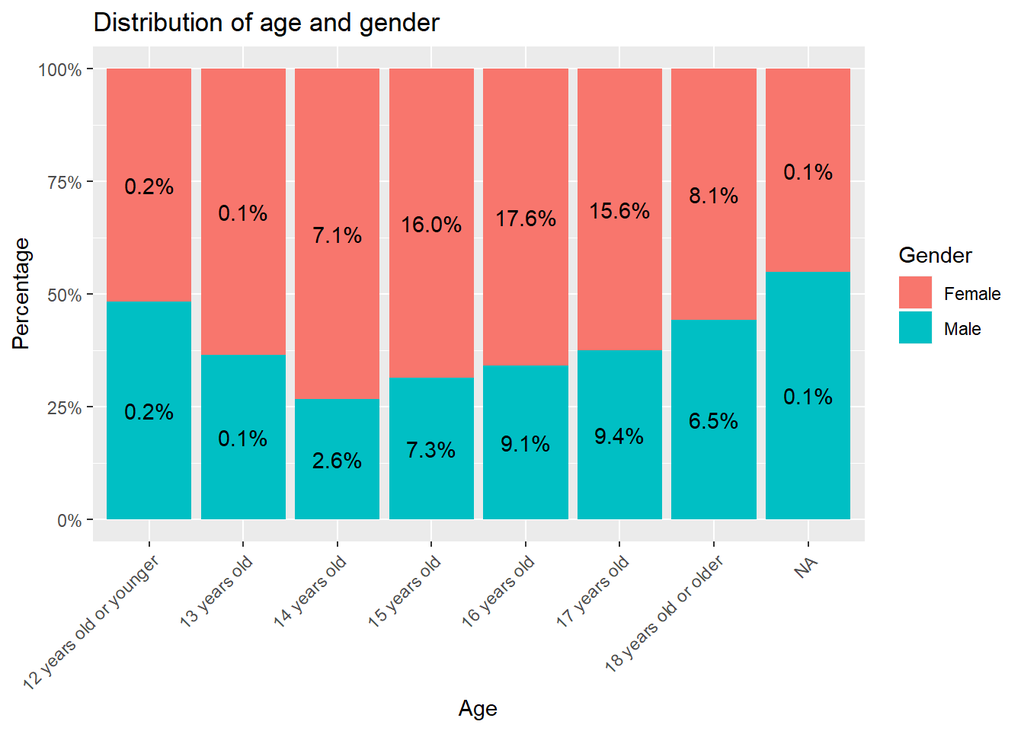

```r
Youth_behavior_data <- Youth_behavior_data[!is.na(Youth_behavior_data$sex_rec), ]
ggplot(Youth_behavior_data, aes(x = Youth_behavior_data$age_rec, fill = Youth_behavior_data$sex_rec)) +geom_bar(position = "fill") + geom_text(aes(label=scales::percent(..count../sum(..count..))), stat='count',position=position_fill(vjust = 0.5))  +
  scale_y_continuous(labels = percent)+ theme(axis.text.x = element_text(angle = 45, hjust = 1)) + xlab("Age") + ylab("Percentage")+ labs(fill="Gender")+ggtitle("Distribution of age and gender")
```

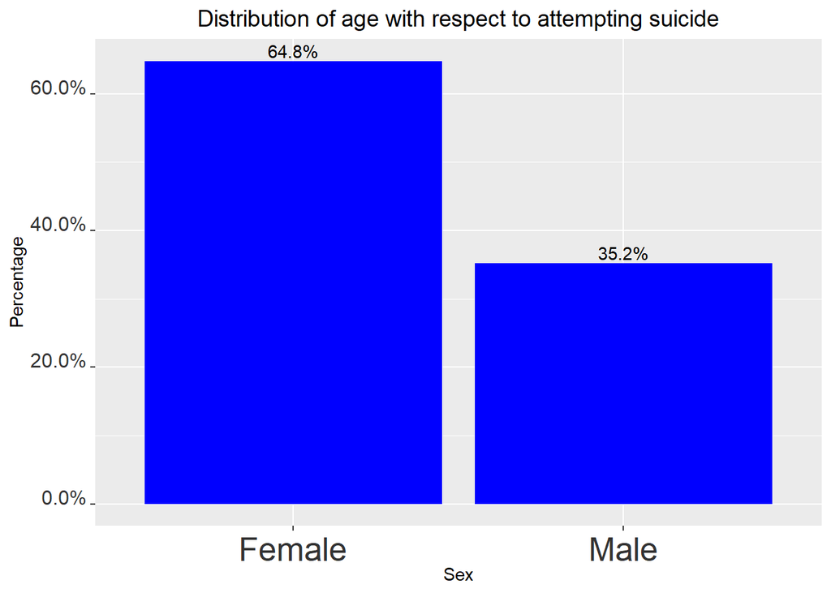

```r
Youth_behavior_data <- Youth_behavior_data[!is.na(Youth_behavior_data$sex_rec), ]
ggplot(Youth_behavior_data, aes(x = Youth_behavior_data$sex_rec)) + geom_bar(aes(y = (..count..)/sum(..count..)), fill = "blue") +
  geom_text(aes(y = ((..count..)/sum(..count..)), label = scales::percent((..count..)/sum(..count..))), stat = "count", vjust = -0.25) +
  scale_y_continuous(labels = percent)+ theme(axis.text.x = element_text(hjust = 1)) + ylab("Percentage") + xlab("Sex") + ggtitle("Distribution of age with respect to attempting suicide") + theme(
    plot.title = element_text(hjust = 0.5, size = 14),    # Center title position and size
    plot.subtitle = element_text(hjust = 0.5),
    axis.text.x = element_text(color = "grey20", size = 20, hjust = .5, vjust = .5, face = "plain"),
    axis.text.y = element_text(color = "grey20", size = 12, angle = 0, hjust = 1, vjust = 0, face = "plain"))            # Center subtitl
```

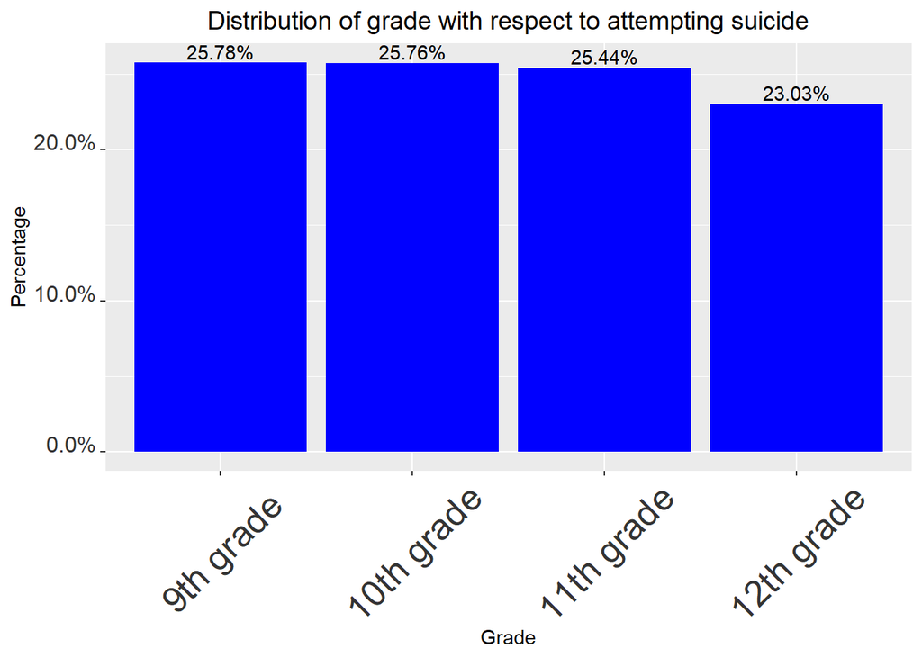

```r
Youth_behavior_data <- Youth_behavior_data[!is.na(Youth_behavior_data$grade_rec), ]
ggplot(Youth_behavior_data, aes(x = Youth_behavior_data$grade_rec)) + geom_bar(aes(y = (..count..)/sum(..count..)), fill = "blue") +
  geom_text(aes(y = ((..count..)/sum(..count..)), label = scales::percent((..count..)/sum(..count..))), stat = "count", vjust = -0.25) +
  scale_y_continuous(labels = percent)+ theme(axis.text.x = element_text(angle = 45, hjust = 1)) + ylab("Percentage") + xlab("Age") + xlab("Grade")  + theme(
    plot.title = element_text(hjust = 0.5, size = 14),    # Center title position and size
    plot.subtitle = element_text(hjust = 0.5),
    axis.text.x = element_text(color = "grey20", size = 20, hjust = .5, vjust = .5, face = "plain"),
    axis.text.y = element_text(color = "grey20", size = 12, angle = 0, hjust = 1, vjust = 0, face = "plain")) + ggtitle("Distribution of grade with respect to attempting suicide")
```

### 43% of the white population had attempted suicide. While, in the survey also most of the population were whites.

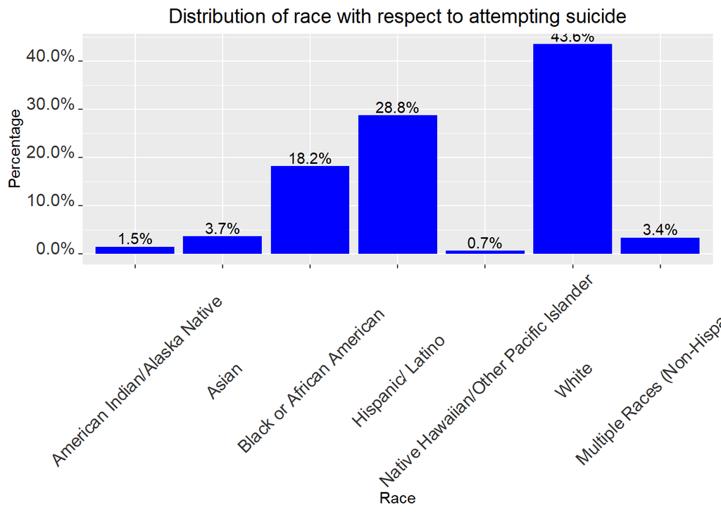

```r
Youth_behavior_data <- Youth_behavior_data[!is.na(Youth_behavior_data$race7_rec), ]


ggplot(Youth_behavior_data, aes(x = Youth_behavior_data$race7_rec)) + geom_bar(aes(y = (..count..)/sum(..count..)), fill = "blue") +
  geom_text(aes(y = ((..count..)/sum(..count..)), label = scales::percent((..count..)/sum(..count..))), stat = "count", vjust = -0.25) +
  scale_y_continuous(labels = percent)+ theme(axis.text.x = element_text(angle = 45, hjust = 1)) + ylab("Percentage") + xlab("Age") + xlab("Race")  + theme(
    plot.title = element_text(hjust = 0.5, size = 14),    # Center title position and size
    plot.subtitle = element_text(hjust = 0.5),
    axis.text.x = element_text(color = "grey20", size = 12, hjust = .5, vjust = .5, face = "plain"),
    axis.text.y = element_text(color = "grey20", size = 12, angle = 0, hjust = 1, vjust = 0, face = "plain")) + ggtitle("Distribution of race with respect to attempting suicide")
```

### 43% of the youth who had attempted suicide had right weight and 32% of them were slightly overweight.

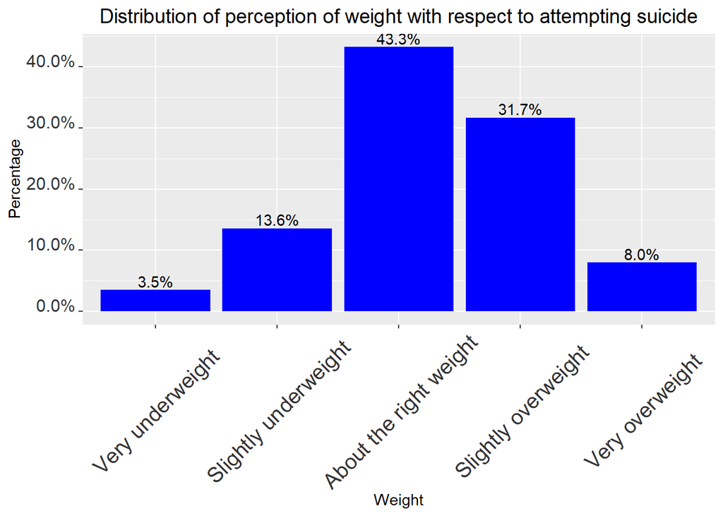

```r
Youth_behavior_data <- Youth_behavior_data[!is.na(Youth_behavior_data$q68_rec), ]
ggplot(Youth_behavior_data, aes(x = Youth_behavior_data$q68_rec)) + geom_bar(aes(y = (..count..)/sum(..count..)), fill = "blue") + geom_text(aes(y = ((..count..)/sum(..count..)), label = scales::percent((..count..)/sum(..count..))), stat = "count", vjust = -0.25) +
  scale_y_continuous(labels = percent)+ theme(axis.text.x = element_text(angle = 45, hjust = 1)) + ylab("Percentage") + xlab("Weight") + theme(
    plot.title = element_text(hjust = 0.5, size = 14),    # Center title position and size
    plot.subtitle = element_text(hjust = 0.5),
    axis.text.x = element_text(color = "grey20", size = 15, hjust = .5, vjust = .5, face = "plain"),
    axis.text.y = element_text(color = "grey20", size = 12, angle = 0, hjust = 1, vjust = 0, face = "plain")) + ggtitle("Distribution of perception of weight with respect to attempting suicide")
```

### 34% of the youth were drinking 1 to 3 times drinking fruit juice and 22% of them did not drink fruit juice drinking who had attempted suicide. This means that they arent having much healthy habits. This can be tested in one of our models.

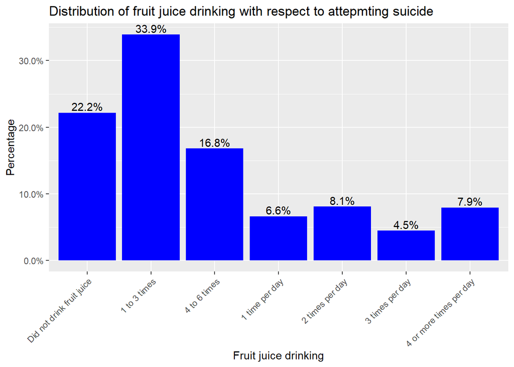

```r
Youth_behavior_data <- Youth_behavior_data[!is.na(Youth_behavior_data$q70_rec), ]
ggplot(Youth_behavior_data, aes(x = Youth_behavior_data$q70_rec)) + geom_bar(aes(y = (..count..)/sum(..count..)), fill = "blue") + geom_text(aes(y = ((..count..)/sum(..count..)), label = scales::percent((..count..)/sum(..count..))), stat = "count", vjust = -0.25) +
  scale_y_continuous(labels = percent)+ theme(axis.text.x = element_text(angle = 45, hjust = 1)) + xlab("Fruit juice drinking") + ylab("Percentage") + ggtitle("Distribution of fruit juice drinking with respect to attepmting suicide")
```

### The 37% of the youth one to three times per week only.

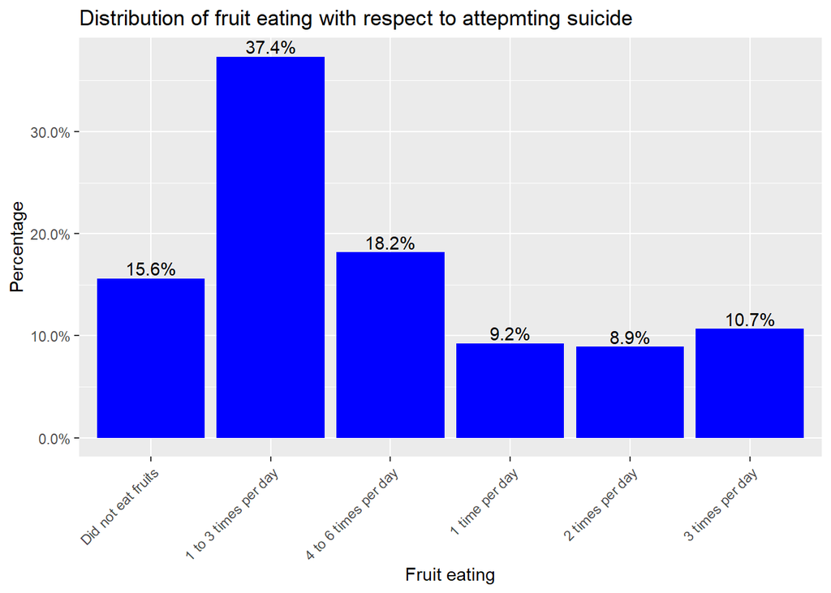

```r
Youth_behavior_data <- Youth_behavior_data[!is.na(Youth_behavior_data$q71_rec), ]
ggplot(Youth_behavior_data, aes(x = Youth_behavior_data$q71_rec)) +geom_bar(aes(y = (..count..)/sum(..count..)), fill = "blue") + geom_text(aes(y = ((..count..)/sum(..count..)), label = scales::percent((..count..)/sum(..count..))), stat = "count", vjust = -0.25) +
  scale_y_continuous(labels = percent)+ theme(axis.text.x = element_text(angle = 45, hjust = 1)) + xlab("Fruit eating") + ylab("Percentage") + ggtitle("Distribution of fruit eating with respect to attepmting suicide")
```

### 76% of the youth who attempted suicide ate less green salad.

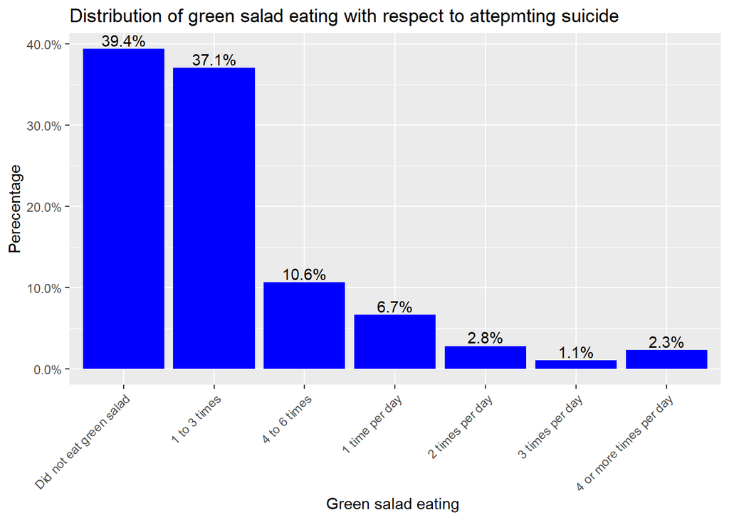

```r
Youth_behavior_data <- Youth_behavior_data[!is.na(Youth_behavior_data$q72_rec), ]
ggplot(Youth_behavior_data, aes(x = Youth_behavior_data$q72_rec)) +geom_bar(aes(y = (..count..)/sum(..count..)), fill = "blue") + geom_text(aes(y = ((..count..)/sum(..count..)), label = scales::percent((..count..)/sum(..count..))), stat = "count", vjust = -0.25) +
  scale_y_continuous(labels = percent)+ xlab("Green salad eating ") + ylab("Perecentage") + theme(axis.text.x = element_text(angle = 45, hjust = 1), axis.text.y = element_text(angle = 0)) + ggtitle("Distribution of green salad eating with respect to attepmting suicide")
```

### 32% of the youth were reported to have 1 to three times of soda drinking per week.

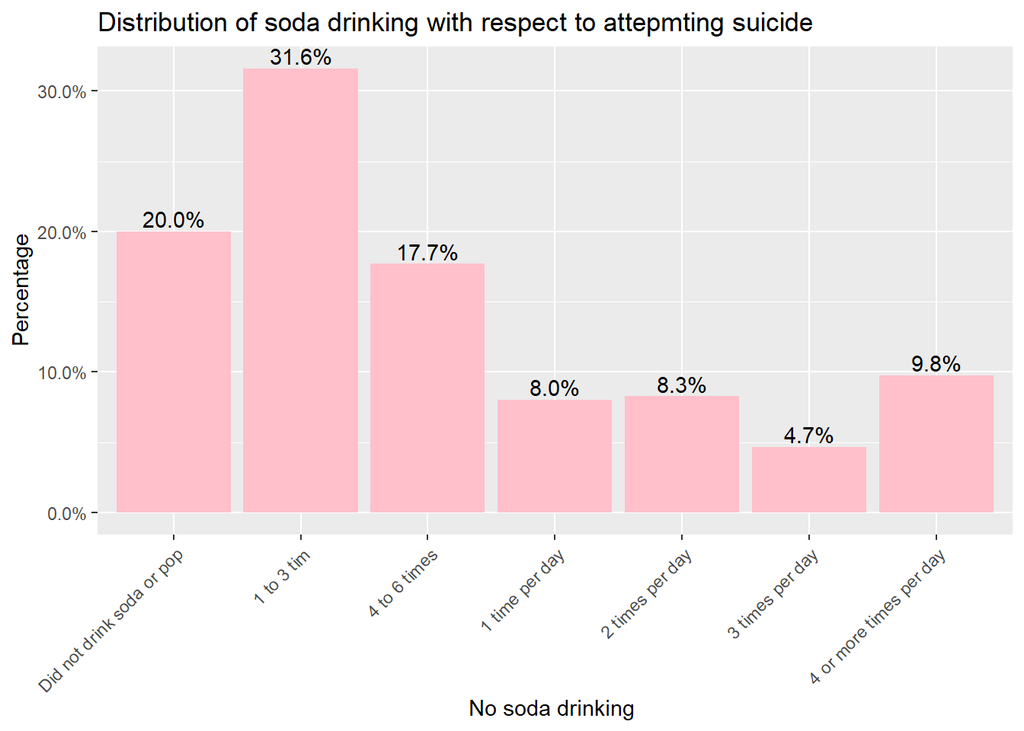

```r
Youth_behavior_data <- Youth_behavior_data[!is.na(Youth_behavior_data$q76_rec), ]
ggplot(Youth_behavior_data, aes(x = Youth_behavior_data$q76_rec)) +geom_bar(aes(y = (..count..)/sum(..count..)), fill = "pink") + geom_text(aes(y = ((..count..)/sum(..count..)), label = scales::percent((..count..)/sum(..count..))), stat = "count", vjust = -0.25) +
  scale_y_continuous(labels = percent)+ theme(axis.text.x = element_text(angle = 45, hjust = 1)) + xlab("No soda drinking ") + ylab("Percentage") + ggtitle("Distribution of soda drinking with respect to attepmting suicide")
```

## 50% of youth who had committed suicide were drinking less milk or no milk in the past one week.

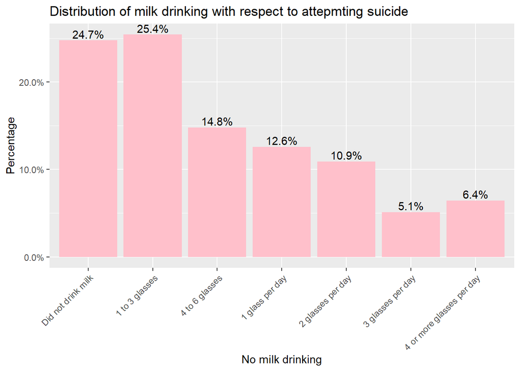

```r
Youth_behavior_data <- Youth_behavior_data[!is.na(Youth_behavior_data$q77_rec), ]
ggplot(Youth_behavior_data, aes(x = Youth_behavior_data$q77_rec)) +geom_bar(aes(y = (..count..)/sum(..count..)), fill = "pink") + geom_text(aes(y = ((..count..)/sum(..count..)), label = scales::percent((..count..)/sum(..count..))), stat = "count", vjust = -0.25) +
  scale_y_continuous(labels = percent)+ theme(axis.text.x = element_text(angle = 45, hjust = 1)) + xlab("No milk drinking") + ylab("Percentage") + ggtitle("Distribution of milk drinking with respect to attepmting suicide")
```

### 39% of the youth were bullied in school who have attempted suicide

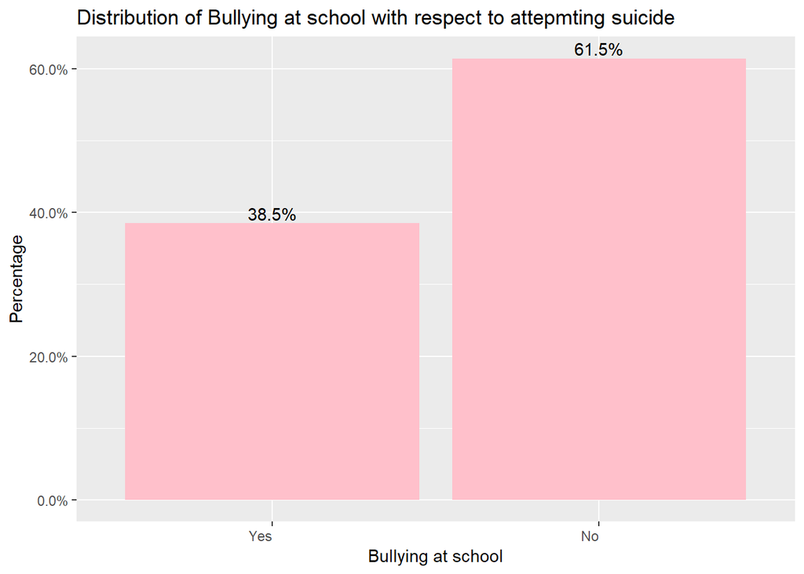

```r
Youth_behavior_data <- Youth_behavior_data[!is.na(Youth_behavior_data$q23_rec), ]
ggplot(Youth_behavior_data, aes(x = Youth_behavior_data$q23_rec)) +geom_bar(aes(y = (..count..)/sum(..count..)), fill = "pink") + geom_text(aes(y = ((..count..)/sum(..count..)), label = scales::percent((..count..)/sum(..count..))), stat = "count", vjust = -0.25) +
  scale_y_continuous(labels = percent)+ theme(axis.text.x = element_text(hjust = 1)) + xlab("Bullying at school") + ylab("Percentage") + ggtitle("Distribution of Bullying at school with respect to attepmting suicide")
```

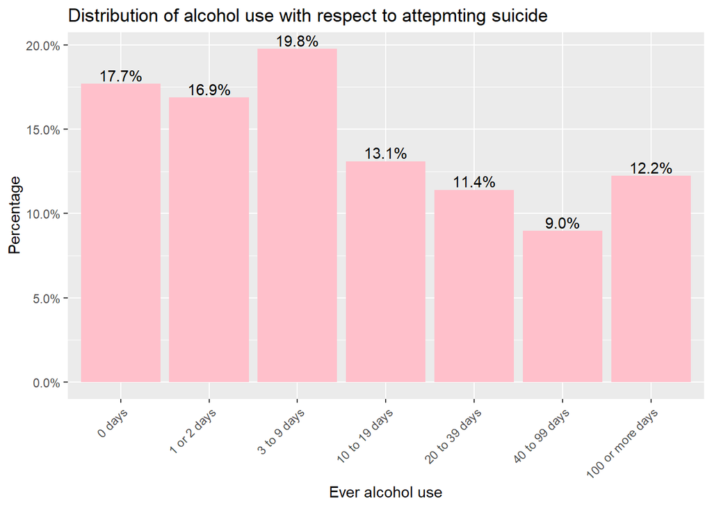

```r
Youth_behavior_data <- Youth_behavior_data[!is.na(Youth_behavior_data$q40_rec), ]
ggplot(Youth_behavior_data, aes(x = Youth_behavior_data$q40_rec)) +geom_bar(aes(y = (..count..)/sum(..count..)), fill = "pink") + geom_text(aes(y = ((..count..)/sum(..count..)), label = scales::percent((..count..)/sum(..count..))), stat = "count", vjust = -0.25) +
  scale_y_continuous(labels = percent)+ theme(axis.text.x = element_text(angle = 45,hjust = 1)) + xlab("Ever alcohol use") + ylab("Percentage") +  ggtitle("Distribution of alcohol use with respect to attepmting suicide")
```

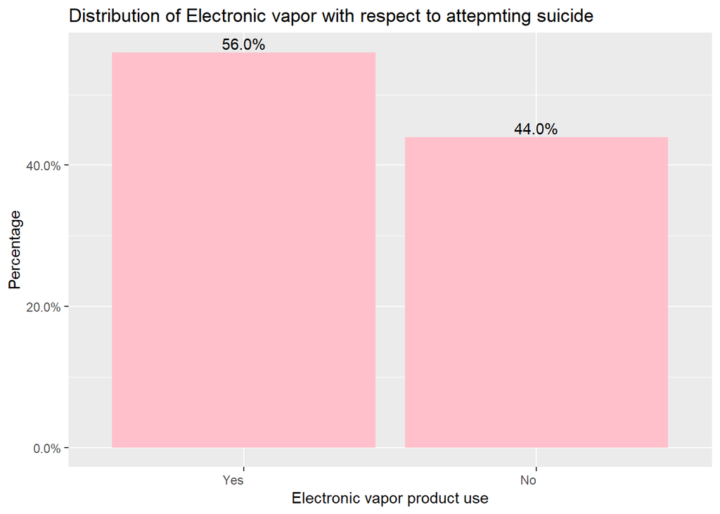

```r
Youth_behavior_data <- Youth_behavior_data[!is.na(Youth_behavior_data$q34_rec), ]
ggplot(Youth_behavior_data, aes(x = Youth_behavior_data$q34_rec)) +geom_bar(aes(y = (..count..)/sum(..count..)), fill = "pink") + geom_text(aes(y = ((..count..)/sum(..count..)), label = scales::percent((..count..)/sum(..count..))), stat = "count", vjust = -0.25) +
  scale_y_continuous(labels = percent)+ theme(axis.text.x = element_text(hjust = 1)) + xlab("Electronic vapor product use") + ylab("Percentage") + ggtitle("Distribution of Electronic vapor with respect to attepmting suicide")
```

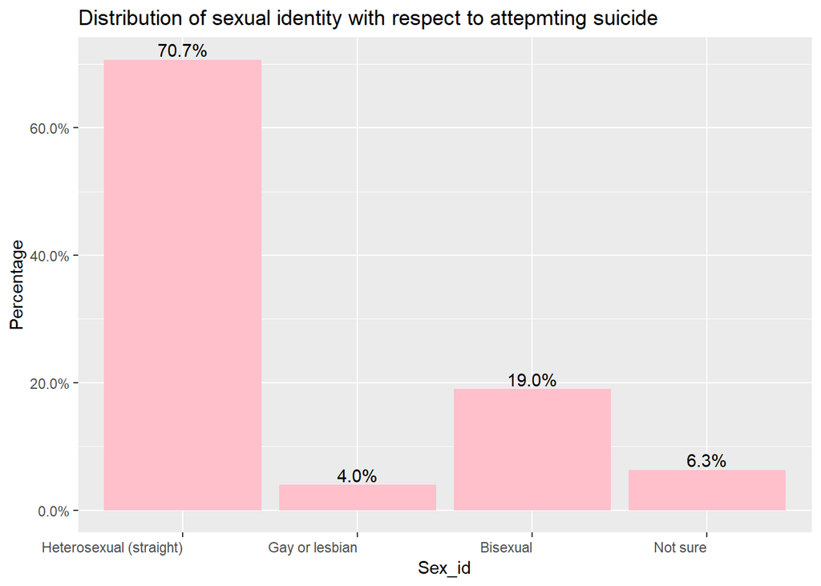

```r
Youth_behavior_data <- Youth_behavior_data[!is.na(Youth_behavior_data$sexid_rec), ]
ggplot(Youth_behavior_data, aes(x = Youth_behavior_data$sexid_rec)) +geom_bar(aes(y = (..count..)/sum(..count..)), fill = "pink") + geom_text(aes(y = ((..count..)/sum(..count..)), label = scales::percent((..count..)/sum(..count..))), stat = "count", vjust = -0.25) +
  scale_y_continuous(labels = percent)+ theme(axis.text.x = element_text(hjust = 1)) + xlab("Sex_id") + ylab("Percentage") + ggtitle("Distribution of sexual identity with respect to attepmting suicide")
```

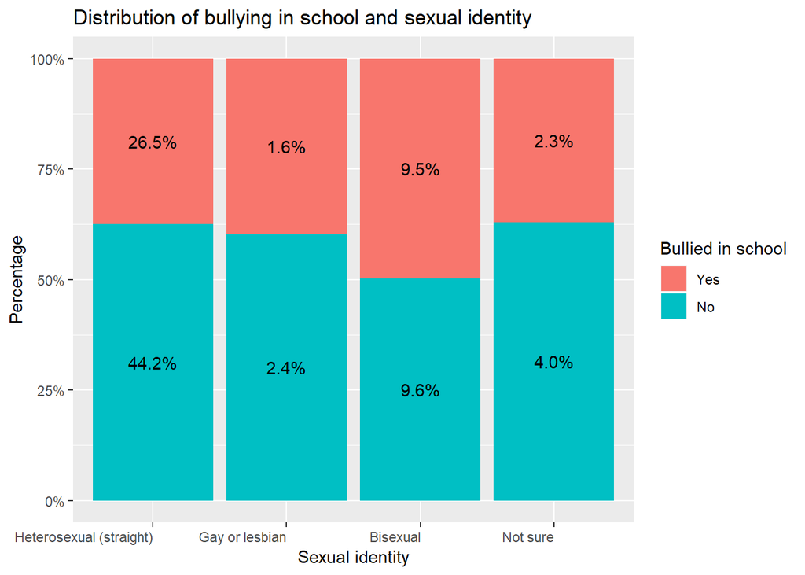

```r
Youth_behavior_data <- Youth_behavior_data[!is.na(Youth_behavior_data$q23_rec), ]
ggplot(Youth_behavior_data, aes(x = Youth_behavior_data$sexid_rec, fill = Youth_behavior_data$q23_rec)) +geom_bar(position = "fill") + geom_text(aes(label=scales::percent(..count../sum(..count..))), stat='count',position=position_fill(vjust = 0.5))  +
  scale_y_continuous(labels = percent)+ theme(axis.text.x = element_text(hjust = 1)) + xlab("Sexual identity") + ylab("Percentage")+ labs(fill="Bullied in school")+ggtitle("Distribution of bullying in school and sexual identity")
```

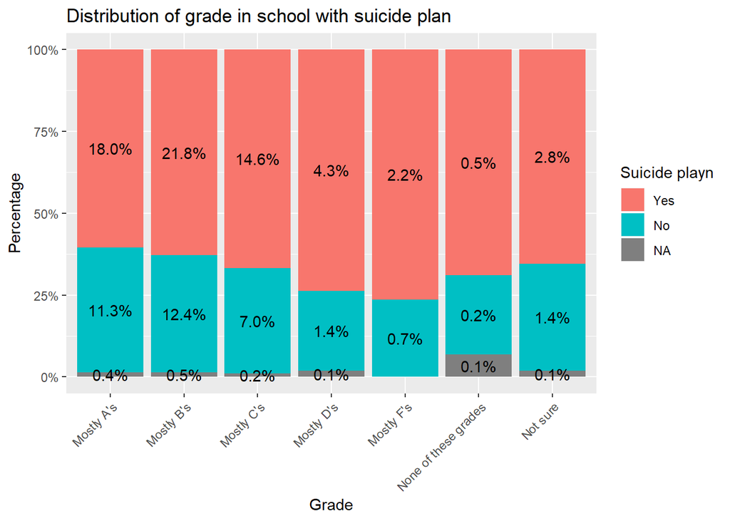

```r
Youth_behavior_data <- Youth_behavior_data[!is.na(Youth_behavior_data$q89_rec), ]
ggplot(Youth_behavior_data, aes(x = Youth_behavior_data$q89_rec, fill = Youth_behavior_data$q27_rec)) +geom_bar(position = "fill") + geom_text(aes(label=scales::percent(..count../sum(..count..))), stat='count',position=position_fill(vjust = 0.5))  +
  scale_y_continuous(labels = percent)+ theme(axis.text.x = element_text(angle = 45,hjust = 1)) + xlab("Grade") + ylab("Percentage")+ labs(fill="Suicide playn") + ggtitle("Distribution of grade in school with suicide plan")
```

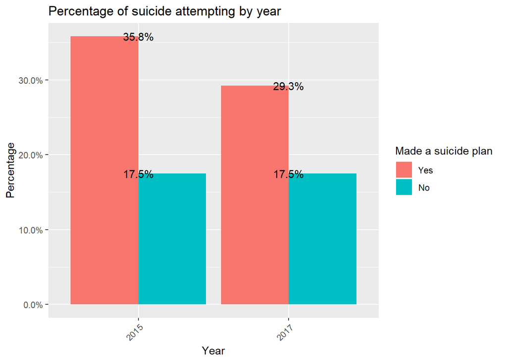

```r
Youth_behavior_data <- Youth_behavior_data[!is.na(Youth_behavior_data$q27_rec), ]
ggplot(Youth_behavior_data, aes(x = Youth_behavior_data$year, fill = Youth_behavior_data$q27_rec)) +geom_bar(aes(y = (..count..)/sum(..count..)), position = "dodge") + geom_text(aes(y = ((..count..)/sum(..count..)), label = scales::percent((..count..)/sum(..count..))), stat = "count") +
  scale_y_continuous(labels = percent)+ theme(axis.text.x = element_text(angle = 45,hjust = 1)) + xlab("Year") + ylab("Percentage") + labs(fill = "Made a suicide plan ") + ggtitle("Percentage of suicide attempting by year")
```

## Models

1. Regression

The youth who attempted suicide is the deoendent variable and below are the independent variables.

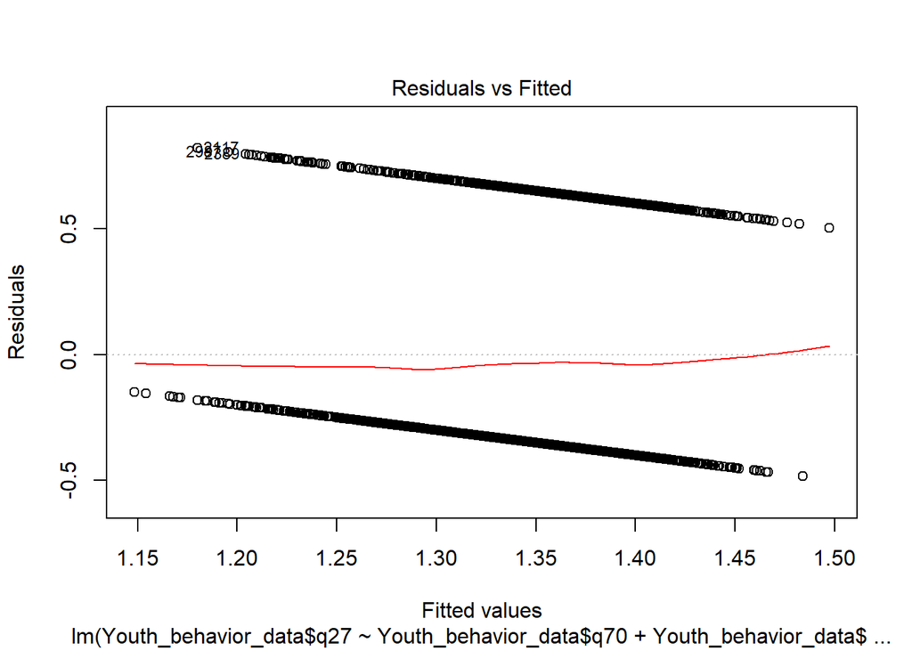

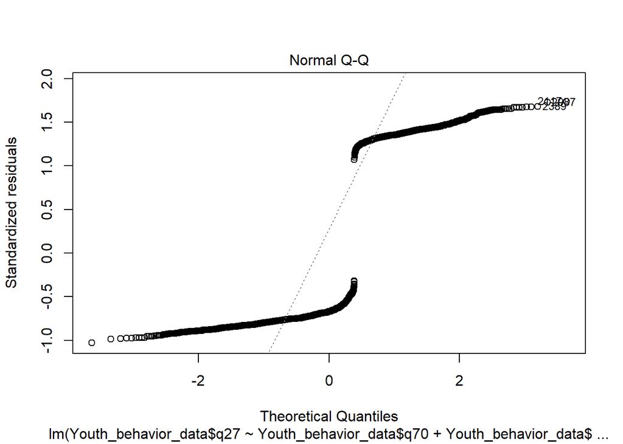

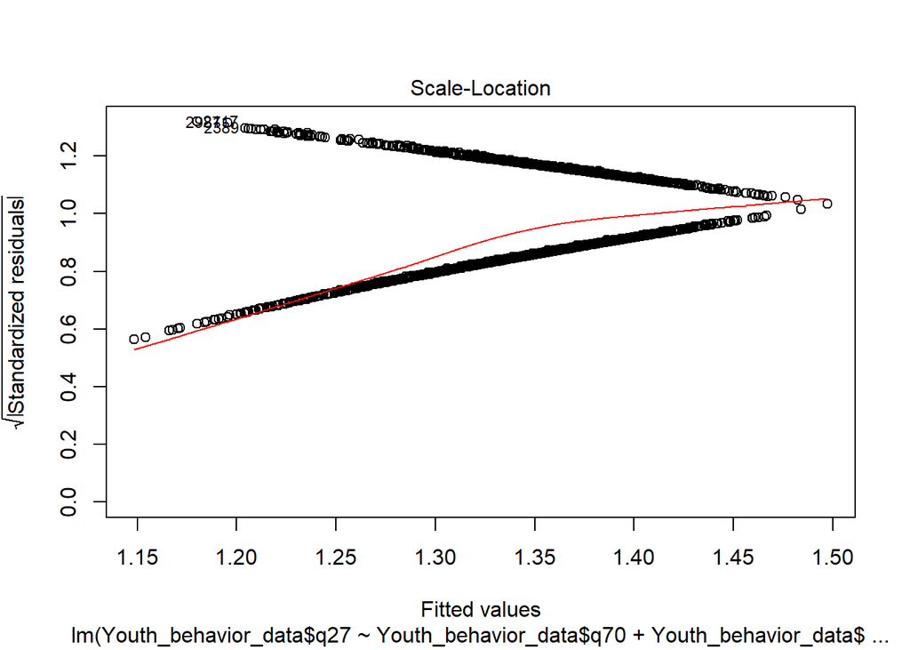

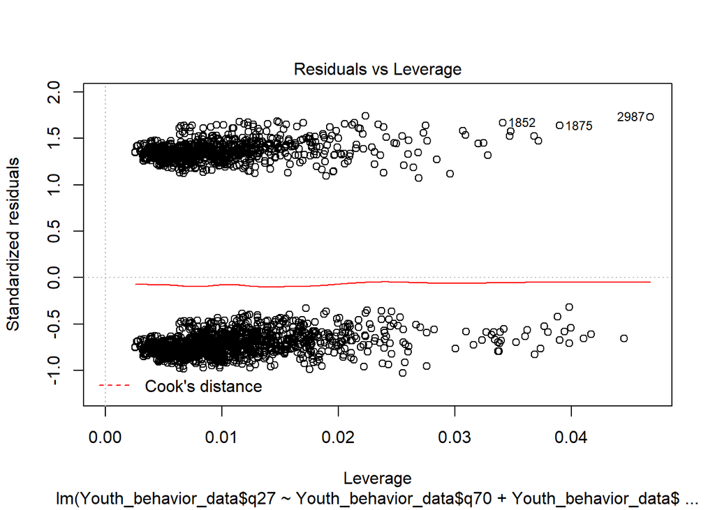

```r
Youth_behavior_data <- Youth_behavior_data %>% filter(q26 == "1")
model1 <- lm(Youth_behavior_data$q27 ~Youth_behavior_data$q70+Youth_behavior_data$q71+Youth_behavior_data$q72+Youth_behavior_data$q76+Youth_behavior_data$q77, data = Youth_behavior_data)
summary(model1)
plot(model1)
```

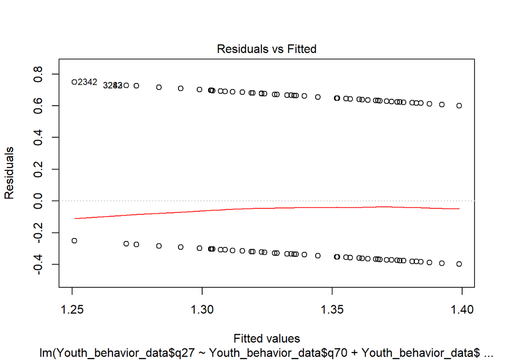

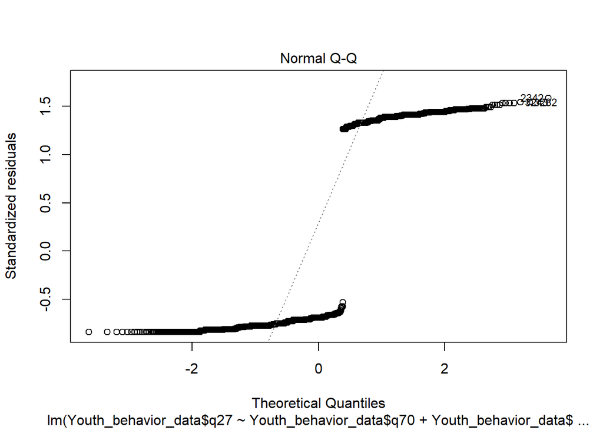

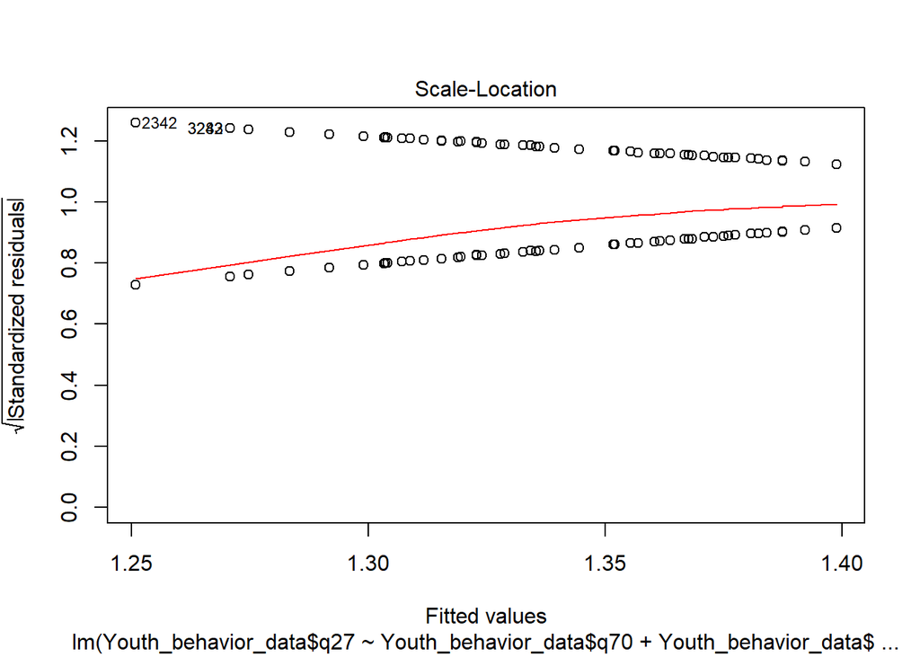

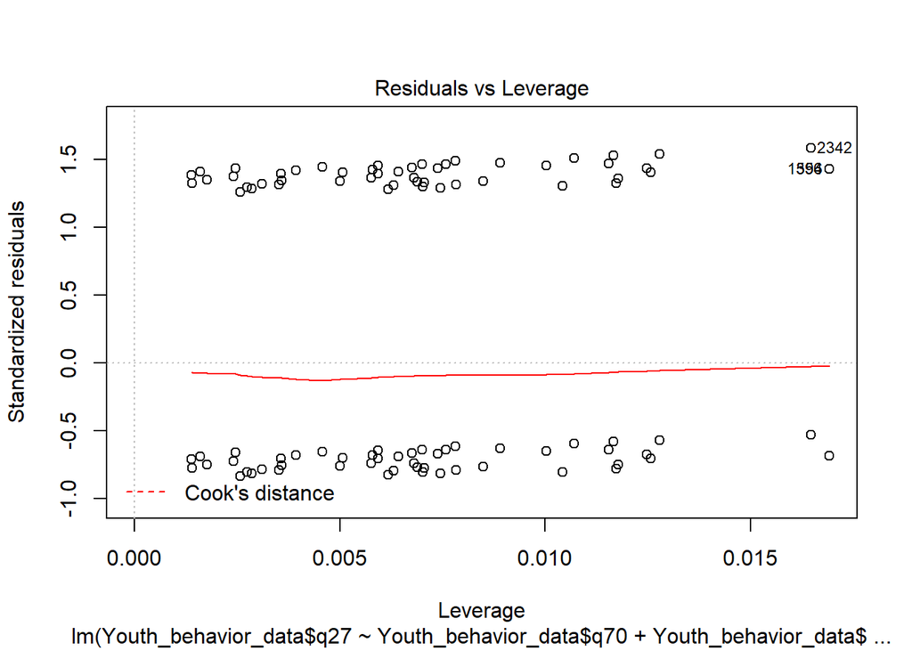

```r
model2 <- lm(Youth_behavior_data$q27 ~Youth_behavior_data$q70+Youth_behavior_data$q77, data = Youth_behavior_data)
summary(model2)
plot(model2)
```

1. Find out the youth who had attempted suiciding and correlation between dietary food habits

```r
model3 <- lm(Youth_behavior_data$q27 ~Youth_behavior_data$q70+Youth_behavior_data$q76+Youth_behavior_data$q77, data = Youth_behavior_data)
summary(model3)
```

2. Which gender has involved in suicide attempts?

```r
model3 <- lm(Youth_behavior_data$q27 ~Youth_behavior_data$sex * Youth_behavior_data$age * Youth_behavior_data$q23, data = Youth_behavior_data)
summary(model3)
```

3. At which age and academic grade, adolescents have thought or have attempted suicide? Find out the factors that lead females to suicide more than males.

```r
model4 <- lm(Youth_behavior_data$q27~Youth_behavior_data$grade*Youth_behavior_data$age)
summary(model4)
library(MASS)
chisq.test(Youth_behavior_data$q27, Youth_behavior_data$sex)
```

```r
Youth_analysis <- Youth_behavior_data %>% filter(sex_rec == "Female")
```

```r
model5 <- glm(Youth_analysis$sex~Youth_analysis$grade*Youth_analysis$age)
summary(model5)
female_youth <- Youth_behavior_data %>% filter(sex_rec == "Female")
```

```r
female_youth <- Youth_behavior_data %>% filter(sex_rec == "Female")
female_youth <- female_youth %>% filter(grade == "3"|grade == "4")
model6 <- lm(female_youth$q27 ~ female_youth$q23 * female_youth$grade, data = female_youth)
summary(model6)
```

4. How does exposure to drug abuse and alcohol, among other factors, contribute to higher rates of violence and suicide attempt among the adolescent population in the United States?

```r
model8 <- lm(Youth_behavior_data$q27~Youth_behavior_data$q40+Youth_behavior_data$q34+Youth_behavior_data$q48+Youth_behavior_data$q49, data = Youth_behavior_data)
summary(model8)
```